# about - jamovi

# About

The jamovi project was founded to develop a free and open statistical platform which is intuitive to use, and can provide the latest developments in statistical methodology. At the core of the jamovi philosophy, is that scientific software should be “community driven”, where anyone can develop and publish analyses, and make them available to a wide audience.

jamovi aims to be a neutral platform, and takes no position with respect to competing statistical philosophies. The project was not founded to promote a particular statistical ideology, instead wanting to serve as a safe space where different statistical approaches might be published side-by-side, and consider themselves first-rate members of the jamovi community.

## Contact Us

If you have any questions about the jamovi project please visit the [forum](https://forum.jamovi.org/).

| E-mail | contact@jamovi.org |
| --- | --- |
| Twitter | [@jamoviStats](https://twitter.com/jamovistats) |
| Facebook | [@jamoviStats](https://www.facebook.com/jamovistats) |
| GitHub | jamovi/jamovi |

## Cite us

Used jamovi for your publication? Please consider adding the following reference:

> The jamovi project (2021). *jamovi* (Version 1.6) [Computer Software]. Retrieved from https://www.jamovi.org

We appreciate that some publications require a city and country of publication, which doesn’t really make sense in the context of an internationally developed open-source project, but if they insist, Sydney, Australia, is probably the best option.

You’ll find additional, analysis specific citations inside jamovi.

## Contribute

Love jamovi? There are a number of ways you can [contribute](https://www.jamovi.org/contribute.html).

## The Team

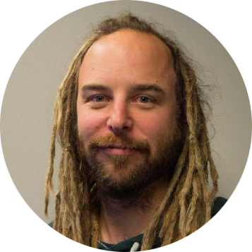

Jonathon Love

Co-founder

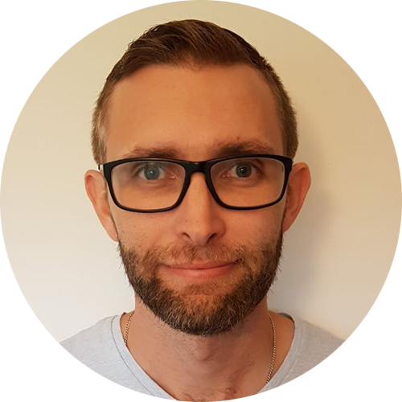

Damian Dropmann

Co-founder

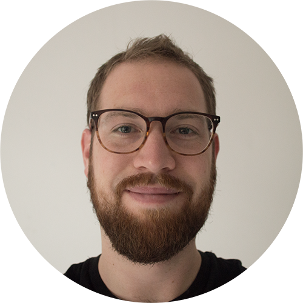

Ravi Selker

Co-founder

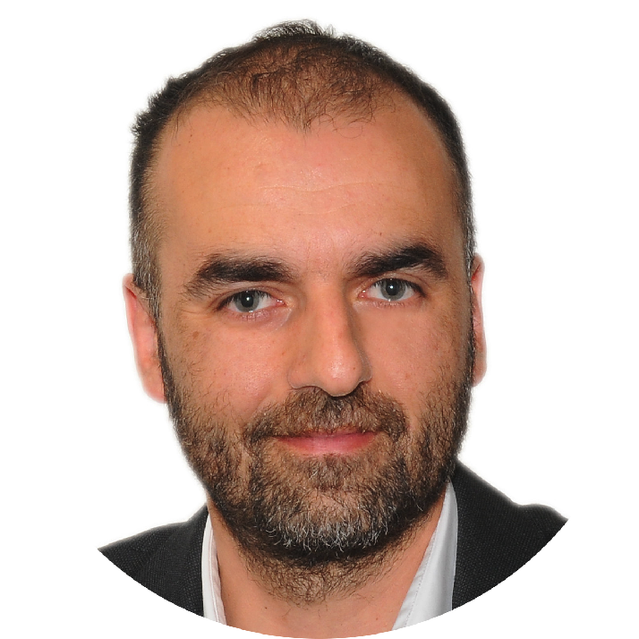

Marcello Gallucci

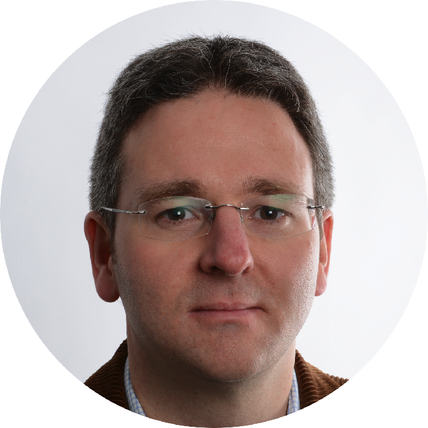

Sebastian Jentschke

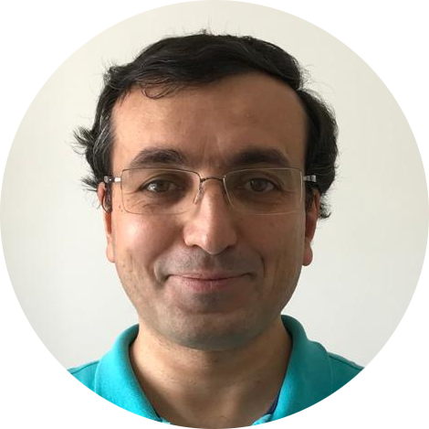

Serdar Balci

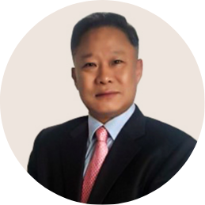

Hyunsoo Seol

Members of the jamovi team have roles and responsibilities as part of the jamovi project, and roles and responsibilities separate from the jamovi project. The actions of individual team members should not be taken as endorsed by the jamovi project, even if jamovi related.